**作者：杨钰萍**

**修改：刘皓昀**，于2018.10.19

# 第三讲 经典分类

## 1 前言

### 1.1 Bayes、Fisher和距离判别法

从贝叶斯公式出发，我们可以得到LDA线性判别分析（分布满足：均值不同，方差相同，高斯分布）、QDA二次判别分析（分布满足：均值不同，方差不同，高斯分布）

Fisher判别法不足：不考虑各总体出现的概率大小，判别方法与错判后造成的损失无关，而这些恰好是贝叶斯的优点

正态等协差阵条件下，Bayes判别法与距离判别法等价

二分类且等协差条件下，Fisher判别法等价于距离判别法

正态等协差阵条件下，Bayes，Fisher线性判别法和距离判别法三者等价

Bayes要求知道总体分布类型（并不要求正态性），理论上可以说明Bayes判别在总体是非正态的情况下也适用，但是丧失正态性后，Bayes判别法具有的平均错判率最小的性质就不一定存在了

Fisher判别法和距离判别法对总体分布没有要求，只要求各类总体的二阶矩存在

当k个总体的均值向量共线性程度高时，Fisher判别法可以用较少的判别函数进行判别，这个时候，比Bayes简单

### 1.2 KNN跟线性回归的对比

K最近邻(KNN)跟线性回归有一个对比（是非参方法与参数方法的对比）

1. 选定的参数形式接近 f 的真实形式，参数方法更优
2. 因为需要估计的系数较少，所以较容易拟合（优）
3. 系数有简单的解释，可以容易地进行统计显著性检验（优）
4. 假设太多，如果目标是预测的准确性，而所指定的函数与实际相差太远，参数方法的表现不佳（缺）
5. 如果 x 和Y的真实关系是近仅线性的，那么线性回归就会比较好， 非线性的情况， KNN 可能会大大优于线性回归
6. KNN 的预测效果随着维数增大而恶化（样本量少的话，参数方法会优于非参数方法）

### 1.3 分类时不使用线性回归

**两水平以上的**定性响应变量，哑变量的方法不能任意推广。这是因为不同种类的编码方式会产生完全不同的线性模型，导致测试观测产生不同的观测结果

**两水平的**定性相应变量，用线性回归模型，原则上一定有一些预测变量值是没有意义的（预测的概率>1或<0的），而考虑使用logistic回归模型就可以避免这一问题

### 1.4 多分类不使用Logistic回归

使用一个预测变量做Logistic回归时，如果其他预测变量与之有关系，那么模型可能会存在风险（只用一个预测变量得到的结果，可能与多个预测变量得到的结果完全不同——**混淆现象**）

当分类数超过2时，一般使用线性判别分析方法

这是因为当类别区分度高时，Logistic回归模型的参数估计不够稳定；$n$较小时，在每一类响应分类中预测变量近似服从正态分布时，线性判别分析模型比Logistic回归模型更稳定

## 2 Logistic回归

$P_r(Y=1|X)=p(X) （1）$

$p(X)=\cfrac{e^{\beta_0+\beta_1X}}{1+e^{\beta_0+\beta_1X}} （2）$

$\cfrac{p(X)}{1-p(X)}=e^{\beta_0+\beta_1X}$

$\log(\cfrac{p(X)}{1-p(X)})=\beta_0+\beta_1X$

$\beta_0$和$\beta_1$可以由极大似然法估计得到，把所估计出来的参数和$X=x$代入$（2）$就可以知道$p(X)$的值，也就是$（1）$中$P_r(Y=1|X)$ 的值，即$Y$分到“1”类的概率，如果这个概率>0.5,则就将所要预测的响应变量分到“1”类，若概率<0.5,则将该响应变量分到“0”类

```r
library(ISLR)
library(MASS)
#划分训练样本和测试样本
dat <- Smarket[, c("Year", "Lag1", "Lag2", "Direction")]
train <- (dat$Year < 2005)#输出布尔值
dattrain <- dat[train,] #以2001-2004年的数据为训练样本
dattest <- dat[!train,] #2005年的数据为测试样本

#Logistic回归建模
glm.fit <- glm(Direction ~ Lag1+Lag2, family = binomial, data = dattrain)#训练集：2001-2004的数据

#Logistic回归预测
glm.probs <- predict(glm.fit, dattest, type = "response")#测试集：2005年的数据，得到2005年的走势预测
glm.pred <- rep("Down", 252) #创建一个有1250个“DOWN”元素的向量
glm.pred[glm.probs > 0.5] = "UP" #把向量中上涨概率大于0.5的变成“UP”

tablogs<-table(glm.pred, dattest$Direction)
tablogs
```

```
##
## glm.pred Down  Up
##     Down   35  35
##     UP     76 106
```

```r
sum(diag(prop.table(tablogs))) #计算正确分类率
```

```
## [1] 0.5595238
```

## 3 线性判别分析

线性判别分析

$W=A^{'}X$

### 3.1 Bayes方法

```r
#数据划分
dattrain1 <- dattrain[dattrain$Direction == "Up",]
dattrain2 <- dattrain[dattrain$Direction == "Down",]
dattrain1 <- as.matrix(dattrain1[, c("Lag1", "Lag2")])
dattrain2 <- as.matrix(dattrain2[, c("Lag1", "Lag2")])
```

**准则：**

1、后验概率最大

2、错判损失最小，以下认为错判损失相同

把$X=x$分到能使$\delta_{k}(x)=-\cfrac{1}{2}(x-\mu_k)^T\Sigma_k^{-1}(x-\mu_k)+\log\pi_k$最大的那一个“$k$”类(后验概率最大)

```r
#计算两类样本均值(列均值)
dattrain1_mean <- apply(dattrain1, 2, mean)
dattrain2_mean <- apply(dattrain2, 2, mean)
pred <- rep("Down", nrow(as.matrix(dattest)))
post <- rep(0, nrow(as.matrix(dattest)))
p1 <- log(nrow(dattrain1) / nrow(dattrain))
p2 <- log(nrow(dattrain2) / nrow(dattrain))
for (i in 1:nrow(as.matrix(dattest))) {
    delta1 <- -1 / 2 * (as.matrix(dattest[, c("Lag1", "Lag2")])[i,] - dattrain1_mean) %*% solve(cov(dattrain1)) %*% (as.matrix(dattest[, c("Lag1", "Lag2")])[i,] - dattrain1_mean) + p1
    delta2 <- -1 / 2 * (as.matrix(dattest[, c("Lag1", "Lag2")])[i,] - dattrain2_mean) %*% solve(cov(dattrain2)) %*% (as.matrix(dattest[, c("Lag1", "Lag2")])[i,] - dattrain2_mean) + p2

    if (delta1 > delta2) {
        pred[i] = "Up"
        post[i] = exp(delta1) / (exp(delta1) + exp(delta2))
    } else {
        pred[i] = "Down"
        post[i] = exp(delta2) / (exp(delta1) + exp(delta2))
    }
}
Bayesresults <- cbind(dattest, as.data.frame(pred), post)
Bayesresults[1:10,]
```

```
##      Year   Lag1   Lag2 Direction pred      post
## 999  2005 -0.134  0.008      Down   Up 0.5098307
## 1000 2005 -0.812 -0.134      Down   Up 0.5212584
## 1001 2005 -1.167 -0.812      Down   Up 0.5334764
## 1002 2005 -0.363 -1.167        Up   Up 0.5232352
## 1003 2005  0.351 -0.363      Down   Up 0.5068117
## 1004 2005 -0.143  0.351        Up   Up 0.5057980
## 1005 2005  0.342 -0.143      Down   Up 0.5048589
## 1006 2005 -0.610  0.342        Up   Up 0.5124110
## 1007 2005  0.398 -0.610      Down   Up 0.5081952
## 1008 2005 -0.863  0.398        Up   Up 0.5152596
```

```r
sum(Bayesresults$Direction == Bayesresults$pred) / nrow(dattest) #计算正确分类率
```

```
## [1] 0.5634921
```

### 3.2 LDA分类器

分类器会将$X=x$分到使$δ_k (x)=x·μ_k/σ^2 -(μ_k^2)/(2σ^2 )+logπ_k$最大的那一个“$k$”类

```r
#前提假设： 每一类中的观测都来自于一个均值不同，方差相同的正态分布假设上
#用LDA建模
lda.fit <- lda(Direction ~ Lag1 + Lag2, data = dattrain)
lda.fit
```

```
## Call:
## lda(Direction ~ Lag1 + Lag2, data = dattrain)
##
## Prior probabilities of groups:
##     Down       Up
## 0.491984 0.508016
##
## Group means:
##             Lag1        Lag2
## Down  0.04279022  0.03389409
## Up   -0.03954635 -0.03132544
##
## Coefficients of linear discriminants:
##             LD1
## Lag1 -0.6420190
## Lag2 -0.5135293
```

```r
#用LDA预测
lda.pred <- predict(lda.fit, dattest)
tablda <- table(dattest$Direction, lda.pred$class)
tablda
```

```
##
##        Down  Up
##   Down   35  76
##   Up     35 106
```

```r
sum(diag(prop.table(tablda))) #计算正确分类率
```

```
## [1] 0.5595238
```

```r
cbind(dattest, lda.pred$class)[1:10,]#输出原数据的类别和训练后的类别
```

```
##      Year   Lag1   Lag2 Direction lda.pred$class
## 999  2005 -0.134  0.008      Down             Up
## 1000 2005 -0.812 -0.134      Down             Up
## 1001 2005 -1.167 -0.812      Down             Up
## 1002 2005 -0.363 -1.167        Up             Up
## 1003 2005  0.351 -0.363      Down             Up
## 1004 2005 -0.143  0.351        Up             Up
## 1005 2005  0.342 -0.143      Down             Up
## 1006 2005 -0.610  0.342        Up             Up
## 1007 2005  0.398 -0.610      Down             Up
## 1008 2005 -0.863  0.398        Up             Up
```

```r
round(lda.pred$posterior, 3)[1:10,] #输出前十个后验概率，保留三位小数
```

```
##       Down    Up
## 999  0.490 0.510
## 1000 0.479 0.521
## 1001 0.467 0.533
## 1002 0.474 0.526
## 1003 0.493 0.507
## 1004 0.494 0.506
## 1005 0.495 0.505
## 1006 0.487 0.513
## 1007 0.491 0.509
## 1008 0.484 0.516
```

### 3.3 QDA分类器

```r
#前提假设： 每一类的观测都服从一个均值不同协方差矩阵相同的多元高斯分布
#用QDA建模
qda.fit <- qda(Direction ~ Lag1 + Lag2, data = dattrain)
qda.fit
```

```
## Call:
## qda(Direction ~ Lag1 + Lag2, data = dattrain)
##
## Prior probabilities of groups:
##     Down       Up
## 0.491984 0.508016
##
## Group means:
##             Lag1        Lag2
## Down  0.04279022  0.03389409
## Up   -0.03954635 -0.03132544
```

```r
#用QDA预测
qda.pred <- predict(qda.fit, dattest)
tabqda <- table(dattest$Direction, qda.pred$class)
tabqda
```

```
##
##        Down  Up
##   Down   30  81
##   Up     20 121
```

```r
sum(diag(prop.table(tabqda))) #计算正确分类率
```

```
## [1] 0.5992063
```

```r
cbind(dattest, qda.pred$class)[1:10,] #输出原数据的类别和训练后的类别
```

```
##      Year   Lag1   Lag2 Direction qda.pred$class
## 999  2005 -0.134  0.008      Down             Up
## 1000 2005 -0.812 -0.134      Down             Up
## 1001 2005 -1.167 -0.812      Down             Up
## 1002 2005 -0.363 -1.167        Up             Up
## 1003 2005  0.351 -0.363      Down             Up
## 1004 2005 -0.143  0.351        Up             Up
## 1005 2005  0.342 -0.143      Down             Up
## 1006 2005 -0.610  0.342        Up             Up
## 1007 2005  0.398 -0.610      Down             Up
## 1008 2005 -0.863  0.398        Up             Up
```

```r
round(qda.pred$post, 3)[1:10,]#输出前十个后验概率，保留三位小数
```

```
##       Down    Up
## 999  0.487 0.513
## 1000 0.476 0.524
## 1001 0.464 0.536
## 1002 0.474 0.526
## 1003 0.490 0.510
## 1004 0.491 0.509
## 1005 0.492 0.508
## 1006 0.485 0.515
## 1007 0.489 0.511
## 1008 0.482 0.518
```

```r
#比较LDA和QDA
sum(diag(prop.table(tabqda))) > sum(diag(prop.table(tablda)))
```

```
## [1] TRUE
```

**结果解读：**QDA模型的正确分类率大于LDA模型，说明这组数据QDA的分类效果比LDA的分类效果好

### 3.4 距离判别法公式分类

计算各类重心即各组的均值，某次观测分到i类，如果它离第i类的重心距离最近（这里的距离可以用欧氏距离，但是马氏距离用的多）

距离计算：$D(X,G_i)=(X-\mu_{i}^{'})(\Sigma_{i}^{-1})(X-\mu_i),i=1,2$其中，$\mu_1,\mu2,\Sigma_1,\Sigma_2$分别是总体$G_1,G_2$的均值向量和协方差矩阵

二分类（两总体）当$\Sigma_1=\Sigma_2=\Sigma$时（多分类也是类似的做法）

距离比较：$W(X)=D(X,G_2)-D(X,G_1)=2[X-\cfrac{1}{2}(\mu_{1}+\mu_{2})]^{'}\Sigma^{-1}(\mu_1-\mu_2)$

判别标准：

（1）$W(X)>0,X\in G_1$

（2）$W(X)<0,X\in G_2$

（3）$W(X)=0,待判$

```r
#计算两类样本均值(列均值)
dattrain1_mean <- apply(dattrain1, 2, mean)
dattrain2_mean <- apply(dattrain2, 2, mean)
#计算协方差矩阵
sigma <- (cov(dattrain1) * nrow(dattrain1) + cov(dattrain2) * nrow(dattrain2)) / (nrow(dattrain1) + nrow(dattrain2) - 2)
solve(sigma) #求逆矩阵
```

```
##            Lag1       Lag2
## Lag1 0.66041852 0.01461352
## Lag2 0.01461352 0.66012566
```

```r
a <- solve(sigma) %*% (dattrain1_mean - dattrain2_mean) #%*%表示矩阵的乘法,Sigma的逆*（mu_1-mu_2）

b = 1 / 2 * (dattrain1_mean + dattrain2_mean)#两个分类的的均值向量的均值
#判断测试集里的属于哪一类
pred <- rep("Down", nrow(as.matrix(dattest)))##全都是"Down"
for (i in 1:nrow(as.matrix(dattest))) {
    W = t(a) %*% t(as.matrix((dattest[, c("Lag1", "Lag2")] - b)))[, i]

    if (W > 0) {
        pred[i] = "Up"
    } else {
        pred[i] = "Down"
    }
}
Distanceresults <- cbind(dattest, as.data.frame(pred))
Distanceresults[1:10,]
```

```
##      Year   Lag1   Lag2 Direction pred
## 999  2005 -0.134  0.008      Down   Up
## 1000 2005 -0.812 -0.134      Down   Up
## 1001 2005 -1.167 -0.812      Down   Up
## 1002 2005 -0.363 -1.167        Up   Up
## 1003 2005  0.351 -0.363      Down Down
## 1004 2005 -0.143  0.351        Up Down
## 1005 2005  0.342 -0.143      Down Down
## 1006 2005 -0.610  0.342        Up   Up
## 1007 2005  0.398 -0.610      Down   Up
## 1008 2005 -0.863  0.398        Up   Up
```

```r
sum(Distanceresults$Direction == Distanceresults$pred) / nrow(dattest) #计算正确分类率
```

```
## [1] 0.547619
```

### 3.5 Fisher判别法公式分类

(假设是p个因子，二分类)

类之间的变异$(\overline{Y}_1-\overline{Y}_2)$尽可能大，类内部的变异$S_{P}^{2}=\cfrac{(n_{1}-1)S_{1}^{2}+(n_{2}-1)S_{2}^{2}}{n_{1}+n_{2}-2}$尽可能小,也就是 $\lambda=\cfrac{(\overline{Y}_1-\overline{Y}_2)^{2}}{S_{P}^{2}}$越大越好,其中$\overline{Y}_1=A^{'}\overline{X}_{1},\overline{Y}_2=A^{'}\overline{X}_{2}$。$——\rightarrow$得到适当的X的线性组合A，得到判别函数$Y=A^{'}X=a_1x_1+a_2x_2+\dots+a_px_p$

参考相关文献：$A=\begin{pmatrix}a_{1}\\a_{2}\\\dots\\a_{p}\end{pmatrix}=\begin{bmatrix}S_{11}&&S_{12}&&\dots&&S_{1p}\\ S_{21}&&S_{22}&&\dots&&S_{2p}\\ \dotsi\\ S_{p1}&&S_{p2}&&\dots&&S_{pp}\end{bmatrix}^{-1}\begin{pmatrix}\overline{X}_{11}-\overline{X}_{21}\\\overline{X}_{12}-\overline{X}_{22}\\\dots\\\overline{X}_{1p}-\overline{X}_{2p}\end{pmatrix}$

判别的界值：$y_{0}=\cfrac{n_1\overline{Y}_1+n_2\overline{Y}_2}{n_1+n_2}$

判别标准：

（1）$\overline{Y}_1<\overline{Y}_2$时，$Y<y_{0}$，则$X \in G_1$,否则$X \in G_2$

（2）$\overline{Y}_1>\overline{Y}_2$时，$Y<y_{0}$，则$X \in G_2$,否则$X \in G_1$

（3）$\overline{Y}_1=\overline{Y}_2$时，待判

```r
c <- 1 / (nrow(dattrain1) + nrow(dattrain2) - 2) * a #%*%表示矩阵的乘法
y0 <- (dattrain1_mean %*% c * nrow(dattrain1) + dattrain2_mean %*% c * nrow(dattrain2)) / nrow(dattrain)
pred <- rep("Down", nrow(as.matrix(dattest)))
for (i in 1:nrow(as.matrix(dattest))) {
    y = t(c) %*% t(as.matrix(dattest[, c("Lag1", "Lag2")]))[, i]
    if (y > y0) {
        pred[i] = "Up"
    } else {
        pred[i] = "Down"
    }
}
Fisherresults <- cbind(dattest, as.data.frame(pred))
Fisherresults[1:10,]
```

```
##      Year   Lag1   Lag2 Direction pred
## 999  2005 -0.134  0.008      Down   Up
## 1000 2005 -0.812 -0.134      Down   Up
## 1001 2005 -1.167 -0.812      Down   Up
## 1002 2005 -0.363 -1.167        Up   Up
## 1003 2005  0.351 -0.363      Down Down
## 1004 2005 -0.143  0.351        Up Down
## 1005 2005  0.342 -0.143      Down Down
## 1006 2005 -0.610  0.342        Up   Up
## 1007 2005  0.398 -0.610      Down   Up
## 1008 2005 -0.863  0.398        Up   Up
```

```r
sum(Fisherresults$Direction == Fisherresults$pred) / nrow(dattest) #计算正确分类率
```

```
## [1] 0.547619
```

**结果解读：**在这个数据下，用Fisher和距离判别法公式实际得到的结果是一样的

## 4 KNN分类器

**KNN决策过程**

```r
library(class)
#knn()函数要求参数是矩阵形式
train.X <-as.matrix(dattrain[,c(2,3)])#训练集自变量的矩阵
test.X <-as.matrix(dattest[,c("Lag1","Lag2")])#测试集自变量的矩阵
train.Direction <-as.matrix(dattrain[,"Direction"])#测试集因变量的矩阵

set.seed(1)#设置随机种子是为了结果具有可重复性
#K=1
knn.predK1 <-knn(train.X, test.X, train.Direction, k = 1)
tabK1<-table(knn.predK1, dattest[,"Direction"])
tabK1
```

```
##
## knn.predK1 Down Up
##       Down   43 58
##       Up     68 83
```

```r
sum(diag(prop.table(tabK1))) #计算正确分类率
```

```
## [1] 0.5
```

```r
#K=3
knn.predK3 <- knn(train.X, test.X, train.Direction, k = 3)
tabK3<-table(knn.predK3, dattest[,"Direction"])
tabK3
```

```
##
## knn.predK3 Down Up
##       Down   48 54
##       Up     63 87
```

```r
sum(diag(prop.table(tabK3))) #计算正确分类率
```

```
## [1] 0.5357143
```

```r
#K=9
knn.predK9 = knn(train.X, test.X, train.Direction, k = 9)
tabK9<-table(knn.predK9, dattest[,"Direction"])
tabK9
```

```
##
## knn.predK9 Down Up
##       Down   45 61
##       Up     66 80
```

```r
sum(diag(prop.table(tabK9))) #计算正确分类率
```

```
## [1] 0.4960317
```

## 5 ROC曲线(详见python)

精准率Precision

召回率Recall

FPR、TPR

对于一个特定的分类器和测试数据集，显然只能得到一个分类结果，即一组FPR和TPR的结果，而要得到一个曲线，我们实际上需要一系列FPR和TPR的值，而要得到多组FPR和TPR的值，我们需要设置不同的threshold值。

假设采用逻辑回归，threshold取0和1时，ROC曲线就会在(0,0)和(1,1)两点。threshold取值越多，ROC曲线越光滑。

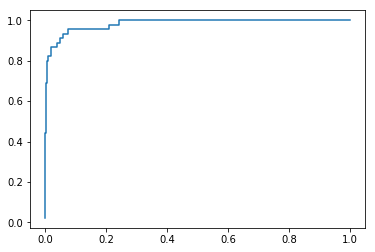

## 6 分类方法比较

```r
#results表示相对应分类方法的正确区分率
methods<-c("Logistic回归","Bayes方法","LDA分类器","QDA分类器","距离判别法公式分类","Fisher判别法公式分类","KNN(K=1)","KNN(K=3)","KNN(K=9)")
results<-c(sum(diag(prop.table(tablogs))),sum(Bayesresults$Direction == Bayesresults$pred) / nrow(dattest),sum(diag(prop.table(tablda))),sum(diag(prop.table(tabqda))),sum(Distanceresults$Direction == Distanceresults$pred) / nrow(dattest),sum(Fisherresults$Direction == Fisherresults$pred) / nrow(dattest),sum(diag(prop.table(tabK1))),sum(diag(prop.table(tabK3))),sum(diag(prop.table(tabK9))))
comparement<-data.frame(methods,results)
comparement
```

```
##                methods   results
## 1         Logistic回归 0.5595238
## 2            Bayes方法 0.5634921
## 3            LDA分类器 0.5595238
## 4            QDA分类器 0.5992063
## 5   距离判别法公式分类 0.5476190
## 6 Fisher判别法公式分类 0.5476190
## 7             KNN(K=1) 0.5000000
## 8             KNN(K=3) 0.5357143
## 9             KNN(K=9) 0.4960317
```

**结果解读：**上述结果表示在这组数据的情况下，QDA分类器的分类效果是相对最好的，KNN的K取值从1->3,分类效果有所提升，但从3->9，分类结果反而变差，说明随着K的继续增加，结果不会再有更进一步的改进

### 6.1 LDA与QDA的比较

观测训练数据量相对较**小**，则LDA优于QDA，反之，QDA优于LDA.因为当数据量**大**时，K类协方差矩阵相同的假设就很容易站不住脚

LDA是关于X的一次函数，QDA是关于X的二次函数。QDA的光滑性更高，即拥有高方差，低偏差。而LDA的光滑性不如QDA，也即拥有更低的方差，且具有改善预测效果的潜力

在具体数据中，QDA与LDA哪个分类器较好，可以在同一个ROC曲线中绘制QDA,LDA，Bayes三个分类器的曲线进行判断

### 6.2 LDA与Logistic、KNN的比较

LDA与Logistic两者都是关于x的线性函数，意味着都产生线性决策边界，而KNN是彻底的非参数方法，对决策边界的形状没有任何假设（也即没有明确的分界线）

当高斯分布的假设近似成立时，LDA比Logistic好，当该假设不成立时，Logistic模型更好

当决策边界高度非线性时，KNN优于LDA与Logistic

KNN的**缺点**在于：（1）必须小心选择光滑水平（2）由于不需要确定、给出参数，因此没有办法确定哪些变量是重要的

### 6.3 总结

光滑度（从低到高）：

1、LDA与Logistic 2、QDA 3、KNN

QDA的光滑度不如KNN但优于LDA与Logistic，对决策边界的形状做了一些假设，且不是线性的。因此QDA的在实际中的应用更广泛一些

如果对于同一观测，LDA与Logistic很好，且Logistic优于LDA,而QDA很差，考虑该观测可能是非正态分布（可能是t分布）